# Similarity-Based Collaborative Filtering

#### Part 3 of the MovieLens Project series

##### Previous articles

- Exploratory Data Analysis of MovieLens Dataset
- Baseline Models for Collaborative Filtering

##### Next articles

- Recommending Movies with Alternating Least Squares
- Recommending Movies with Stochastic Gradient Descent
- Comparing Collaborative Filtering Models

This is the third post of a project on collaborative filtering based on the MovieLens 100K dataset. The remainder of this post is straight out of a Jupyter Notebook file you can download here. You can also see it [here](https://github.com/benlindsay/movielens-analysis/blob/master/03_Similarity-based_CF.ipynb) on GitHub.

Now that we've established some simple baseline models and demonstrated that the Damped User + Movie Baseline model is the best of the few we tested, let's move on to some actual collaborative filtering models. Here, we'll explore user-based and item-based collaborative filtering.

[figure not shown]

*Image found on [www.selemmarafi.com](http://www.salemmarafi.com/wp-content/uploads/2014/04/collaborativeFiltering-960x540.jpg)*

The idea of these methods is simply to predict unseen ratings by looking at how similar users rated a particular item, or by looking at how similar items were rated by a particular user. Both methods fall under the category of K-Nearest Neighbor (KNN) models, since ratings from the K most similar users or items are combined for the prediction.

Below, I've implemented a class called `KNNRecommender` that can accept a `mode` parameter of either `'user'` or `'item'`. Let's see how it compares to our best baseline!

# 1. Import necessary modules and classes

Expand Code

# 2. Load the Data

Let's load and examine the ratings data. If you're following along (i.e. actually running these notebooks) you'll need to make sure to run the first one to download the data before running this one.

Expand Code

```
First 5:
```

|  | userId | movieId | rating | timestamp |
| --- | --- | --- | --- | --- |
| 214 | 259 | 255 | 4 | 1997-09-19 23:05:10 |
| 83965 | 259 | 286 | 4 | 1997-09-19 23:05:27 |
| 43027 | 259 | 298 | 4 | 1997-09-19 23:05:54 |
| 21396 | 259 | 185 | 4 | 1997-09-19 23:06:21 |
| 82655 | 259 | 173 | 4 | 1997-09-19 23:07:23 |

```
Last 5:
```

|  | userId | movieId | rating | timestamp |
| --- | --- | --- | --- | --- |
| 46773 | 729 | 689 | 4 | 1998-04-22 19:10:38 |
| 73008 | 729 | 313 | 3 | 1998-04-22 19:10:38 |
| 46574 | 729 | 328 | 3 | 1998-04-22 19:10:38 |
| 64312 | 729 | 748 | 4 | 1998-04-22 19:10:38 |
| 79208 | 729 | 272 | 4 | 1998-04-22 19:10:38 |

# 3. Write our KNNRecommender class

Expand Code

# 4. Determine Optimal $k$ Values

Expand Code

Expand Code

|  | k | mode | i_fold |
| --- | --- | --- | --- |
| 0 | 1 | user | 0 |
| 1 | 1 | user | 1 |
| 2 | 1 | user | 2 |
| 3 | 1 | user | 3 |
| 4 | 1 | user | 4 |
| 5 | 1 | item | 0 |
| 6 | 1 | item | 1 |
| 7 | 1 | item | 2 |
| 8 | 1 | item | 3 |
| 9 | 1 | item | 4 |

Expand Code

```
(100000, 4)
k=1, mode=item, i_fold=0: MAE=0.807   dt=3.55 seconds
k=1, mode=item, i_fold=1: MAE=0.812   dt=1.68 seconds
k=1, mode=item, i_fold=2: MAE=0.803   dt=1.62 seconds
k=1, mode=item, i_fold=3: MAE=0.806   dt=1.60 seconds
k=1, mode=item, i_fold=4: MAE=0.807   dt=1.81 seconds
k=1, mode=user, i_fold=0: MAE=0.827   dt=1.68 seconds
k=1, mode=user, i_fold=1: MAE=0.834   dt=1.66 seconds
k=1, mode=user, i_fold=2: MAE=0.835   dt=1.53 seconds
k=1, mode=user, i_fold=3: MAE=0.835   dt=1.26 seconds
k=1, mode=user, i_fold=4: MAE=0.833   dt=1.59 seconds
k=2, mode=item, i_fold=0: MAE=0.758   dt=1.90 seconds
k=2, mode=item, i_fold=1: MAE=0.768   dt=1.59 seconds
k=2, mode=item, i_fold=2: MAE=0.758   dt=1.52 seconds
k=2, mode=item, i_fold=3: MAE=0.759   dt=1.45 seconds
k=2, mode=item, i_fold=4: MAE=0.760   dt=1.50 seconds
k=2, mode=user, i_fold=0: MAE=0.785   dt=1.31 seconds
k=2, mode=user, i_fold=1: MAE=0.788   dt=1.32 seconds
k=2, mode=user, i_fold=2: MAE=0.788   dt=1.35 seconds
k=2, mode=user, i_fold=3: MAE=0.787   dt=1.33 seconds
k=2, mode=user, i_fold=4: MAE=0.788   dt=1.26 seconds
k=5, mode=item, i_fold=0: MAE=0.730   dt=1.41 seconds
k=5, mode=item, i_fold=1: MAE=0.741   dt=1.51 seconds
k=5, mode=item, i_fold=2: MAE=0.735   dt=1.65 seconds
k=5, mode=item, i_fold=3: MAE=0.731   dt=1.39 seconds
k=5, mode=item, i_fold=4: MAE=0.731   dt=1.67 seconds
k=5, mode=user, i_fold=0: MAE=0.753   dt=1.56 seconds
k=5, mode=user, i_fold=1: MAE=0.763   dt=1.64 seconds
k=5, mode=user, i_fold=2: MAE=0.756   dt=1.35 seconds
k=5, mode=user, i_fold=3: MAE=0.754   dt=1.31 seconds
k=5, mode=user, i_fold=4: MAE=0.755   dt=1.44 seconds
k=10, mode=item, i_fold=0: MAE=0.725   dt=1.59 seconds
k=10, mode=item, i_fold=1: MAE=0.734   dt=1.66 seconds
k=10, mode=item, i_fold=2: MAE=0.729   dt=1.76 seconds
k=10, mode=item, i_fold=3: MAE=0.723   dt=1.56 seconds
k=10, mode=item, i_fold=4: MAE=0.726   dt=1.44 seconds
k=10, mode=user, i_fold=0: MAE=0.745   dt=1.37 seconds
k=10, mode=user, i_fold=1: MAE=0.752   dt=1.38 seconds
k=10, mode=user, i_fold=2: MAE=0.746   dt=1.75 seconds
k=10, mode=user, i_fold=3: MAE=0.743   dt=1.32 seconds
```

[output cut: 26 more lines]

```
k=100, mode=user, i_fold=0: MAE=0.745   dt=1.36 seconds
k=100, mode=user, i_fold=1: MAE=0.753   dt=1.31 seconds
k=100, mode=user, i_fold=2: MAE=0.746   dt=1.31 seconds
k=100, mode=user, i_fold=3: MAE=0.741   dt=1.46 seconds
k=100, mode=user, i_fold=4: MAE=0.747   dt=1.58 seconds
k=200, mode=item, i_fold=0: MAE=0.741   dt=2.06 seconds
k=200, mode=item, i_fold=1: MAE=0.751   dt=1.55 seconds
k=200, mode=item, i_fold=2: MAE=0.743   dt=1.55 seconds
k=200, mode=item, i_fold=3: MAE=0.739   dt=1.54 seconds
k=200, mode=item, i_fold=4: MAE=0.744   dt=1.73 seconds
k=200, mode=user, i_fold=0: MAE=0.748   dt=1.43 seconds
k=200, mode=user, i_fold=1: MAE=0.757   dt=1.43 seconds
k=200, mode=user, i_fold=2: MAE=0.749   dt=1.39 seconds
k=200, mode=user, i_fold=3: MAE=0.744   dt=1.34 seconds
k=200, mode=user, i_fold=4: MAE=0.751   dt=1.35 seconds
```

Expand Code

```
i_fold=0: MAE=0.755
i_fold=1: MAE=0.765
i_fold=2: MAE=0.757
i_fold=3: MAE=0.752
i_fold=4: MAE=0.759
```

Expand Code

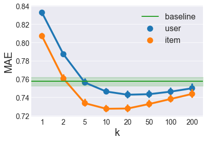

We also see that the best Item-based CF model occurs around $k=10$ while the best User-based CF model occurs around $k=20$. We'll keep these in mind when comparing models later.

Next, we'll look at matrix factorization methods like Alternating Least Squares, so check out the next post/notebook!

#### Part 3 of the MovieLens Project series

##### Previous articles

- Exploratory Data Analysis of MovieLens Dataset
- Baseline Models for Collaborative Filtering

##### Next articles

- Recommending Movies with Alternating Least Squares
- Recommending Movies with Stochastic Gradient Descent
- Comparing Collaborative Filtering Models